# Final Project

Andrés Castro Araújo & Jon Campbell

December 14, 2017

# Introduction

Build a classifier

1. Exploratory Data Analysis: Cluster A. + Scree Plot
2. Supervised Learning

## Data

```r
## Upload data
mdf <- read_csv("beatsdataset.csv")
mdf$X1 <- NULL
mdf$class <- as.factor(mdf$class)

names(mdf) <- make.names(names(mdf))
```

Description of features:

This dataset was downloaded from [Kaggle](https://www.kaggle.com/caparrini/beatsdataset).

# Exploratory Data Analysis

## PCA

We first perform principal components analysis in exploratory analysis to see if the number of meaningful features may be reduced for interpretation. 71 features is much to consider without detailed study of audio analysis. It is possible that these can be boiled down into just a few concepts meaningful for substantive analysis.

```r
mdf <- read_csv("~/Documents/Data Mining/data mining final/beatsdataset.csv")
mdf <- mdf[, - 1]

mdf$class <- as.factor(mdf$class)

names(mdf) <- make.names(names(mdf))

mdf_PCA <- mdf[, - 72]

pr_out <- prcomp(mdf_PCA, scale = TRUE)

pr_out$sdev
```

```
##  [1] 3.52777493 3.23767977 2.70166512 1.95344422 1.68771487 1.65212570
##  [7] 1.59267186 1.48805252 1.39497966 1.36135312 1.23684885 1.20396819
## [13] 1.17101000 1.11271734 1.10383812 1.07891433 0.97379228 0.92608528
## [19] 0.90129839 0.88491608 0.87130485 0.84462474 0.83310601 0.79416761
## [25] 0.77229442 0.76346945 0.74217524 0.71501701 0.69560006 0.67559882
## [31] 0.65190840 0.62272209 0.60667340 0.60227604 0.57556440 0.56272416
## [37] 0.49864963 0.47881679 0.44642318 0.44449075 0.42223460 0.40199327
## [43] 0.39963242 0.37836717 0.37652790 0.36879708 0.36398927 0.35227732
## [49] 0.34691621 0.33220805 0.32574074 0.30902233 0.29653621 0.27676893
## [55] 0.27334689 0.25683950 0.24246932 0.23887115 0.23642029 0.23050017
## [61] 0.22744929 0.20884254 0.19874592 0.19024973 0.16466514 0.15830534
## [67] 0.14544423 0.09873182 0.08275919 0.07690775 0.07040325
```

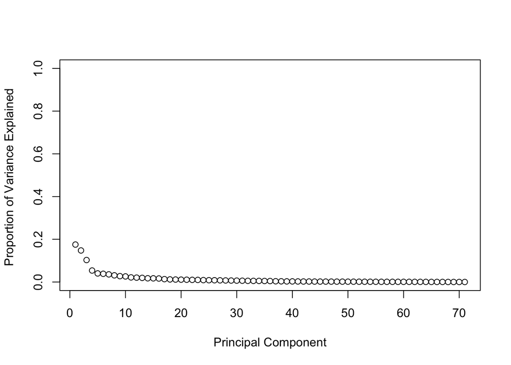

```r
pr.var <- pr_out$sdev^2

pve <- pr.var / sum(pr.var)

plot(pve, xlab="Principal Component", ylab="Proportion of Variance Explained ", ylim=c(0,1),type='b')
```

```r
cumsum(pve)
```

```
##  [1] 0.1752844 0.3229263 0.4257290 0.4794747 0.5195928 0.5580367 0.5937635
##  [8] 0.6249508 0.6523588 0.6784614 0.7000078 0.7204239 0.7397375 0.7571760
## [15] 0.7743374 0.7907326 0.8040885 0.8161679 0.8276093 0.8386385 0.8493311
## [22] 0.8593788 0.8691544 0.8780375 0.8864381 0.8946477 0.9024058 0.9096065
## [29] 0.9164214 0.9228501 0.9288358 0.9342975 0.9394814 0.9445903 0.9492562
## [36] 0.9537161 0.9572183 0.9604474 0.9632543 0.9660370 0.9685480 0.9708241
## [43] 0.9730734 0.9750898 0.9770866 0.9790023 0.9808683 0.9826162 0.9843113
## [50] 0.9858657 0.9873601 0.9887051 0.9899436 0.9910225 0.9920749 0.9930040
## [57] 0.9938320 0.9946357 0.9954229 0.9961713 0.9968999 0.9975142 0.9980705
## [64] 0.9985803 0.9989622 0.9993152 0.9996131 0.9997504 0.9998469 0.9999302
## [71] 1.0000000
```

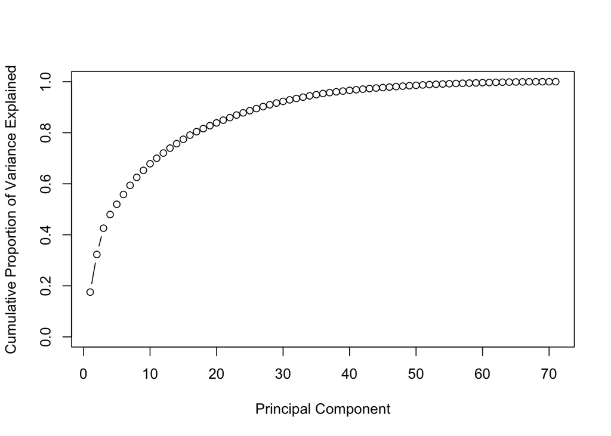

```r
plot(cumsum(pve), xlab = "Principal Component", ylab = "Cumulative Proportion of Variance Explained", ylim = c(0,1), type = 'b')
```

Scree plots indicate that fair gains in amounts of outcome variance can be explained with each additional component until number 30 or so, but this is still too many for cursory examination of our features. The first plot indicates that the first four components are most important, so we investigate these further.

```r
X <- as.matrix(mdf_PCA)

robust_PCA <- PCAproj(X, k = 4, scale = sd)
robust_PCA$loadings
```

```
##
## Loadings:
##                         Comp.1 Comp.2 Comp.3 Comp.4
## X1.ZCRm                 -0.199         0.210 -0.172
## X2.Energym                             0.154  0.199
## X3.EnergyEntropym       -0.213 -0.125
## X4.SpectralCentroidm    -0.165         0.283 -0.141
## X5.SpectralSpreadm                     0.270 -0.134
## X6.SpectralEntropym     -0.224         0.197 -0.110
## X7.SpectralFluxm         0.234
## X8.SpectralRolloffm     -0.191         0.223 -0.173
## X9.MFCCs1m              -0.193 -0.112
## X10.MFCCs2m              0.196        -0.205
## X11.MFCCs3m              0.132         0.140 -0.204
## X12.MFCCs4m              0.142
## X13.MFCCs5m              0.116         0.166
## X14.MFCCs6m              0.107         0.107
## X15.MFCCs7m                            0.148
## X16.MFCCs8m
## X17.MFCCs9m
## X18.MFCCs10m                                  0.101
## X19.MFCCs11m                                  0.108
## X20.MFCCs12m
## X21.MFCCs13m
## X22.ChromaVector1m                    -0.150 -0.155
## X23.ChromaVector2m                    -0.120
## X24.ChromaVector3m                     0.139  0.288
## X25.ChromaVector4m                    -0.145 -0.121
## X26.ChromaVector5m                    -0.108 -0.207
## X27.ChromaVector6m                    -0.178
## X28.ChromaVector7m       0.156
## X29.ChromaVector8m      -0.131
## X30.ChromaVector9m                    -0.167
## X31.ChromaVector10m                   -0.122 -0.156
## X32.ChromaVector11m      0.116
## X33.ChromaVector12m     -0.125        -0.153
## X34.ChromaDeviationm     0.182         0.104  0.231
## X35.ZCRstd                      0.196  0.195 -0.202
## X36.Energystd            0.110  0.108
## X37.EnergyEntropystd     0.137  0.192
```

[output cut: 24 more lines]

```
## X62.ChromaVector7std     0.175
## X63.ChromaVector8std    -0.120
## X64.ChromaVector9std                  -0.159
## X65.ChromaVector10std                        -0.133
## X66.ChromaVector11std    0.131
## X67.ChromaVector12std   -0.111        -0.150
## X68.ChromaDeviationstd   0.117  0.158  0.115
## X69.BPM                                       0.152
## X70.BPMconf                                  -0.114
## X71.BPMessentia                -0.105
##
##                Comp.1 Comp.2 Comp.3 Comp.4
## SS loadings     1.000  1.000  1.000  1.000
## Proportion Var  0.014  0.014  0.014  0.014
## Cumulative Var  0.014  0.028  0.042  0.056
```

Examination of factor loadings indicate that particular features do not load strongly onto the four components, however groups can be discerned, such as `MFCC` features loading onto components 1 and 2, and those beginning with `Spectral` or `Chroma` load on onto component 3. `BPM`-related features load mostly onto component 4.

## Clustering

We can also perform clustering to see if songs may easily be related by genre according to the predictors. Since songs are coded into 23 categories of genre, we might expect to see approximately the same number of clusters.

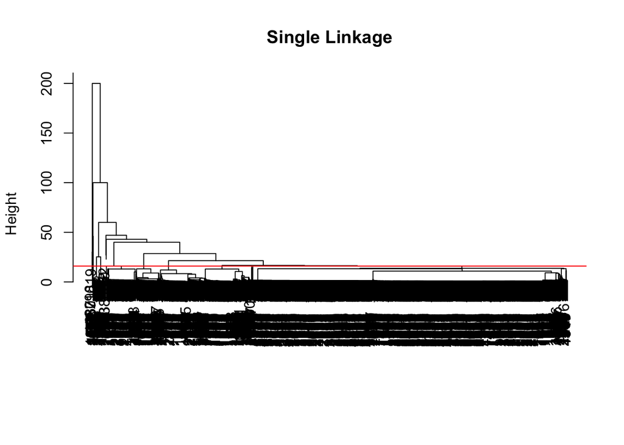

```r
hc_complete <- hclust(dist(X), method = "complete")
hc_average <- hclust(dist(X), method = "average")
hc_single <- hclust(dist(X), method = "single")

plot(hc_single, main = "Single Linkage", xlab = "", sub = "")
abline(h = 16, col = 2)
```

```r
singclust <- table(cutree(hc_single, 16))
singclust
```

```
##
##    1    2    3    4    5    6    7    8    9   10   11   12   13   14   15
## 1522  215  144  226  116   34    2    6   23    6    1    1    1    1    1
##   16
##    1
```

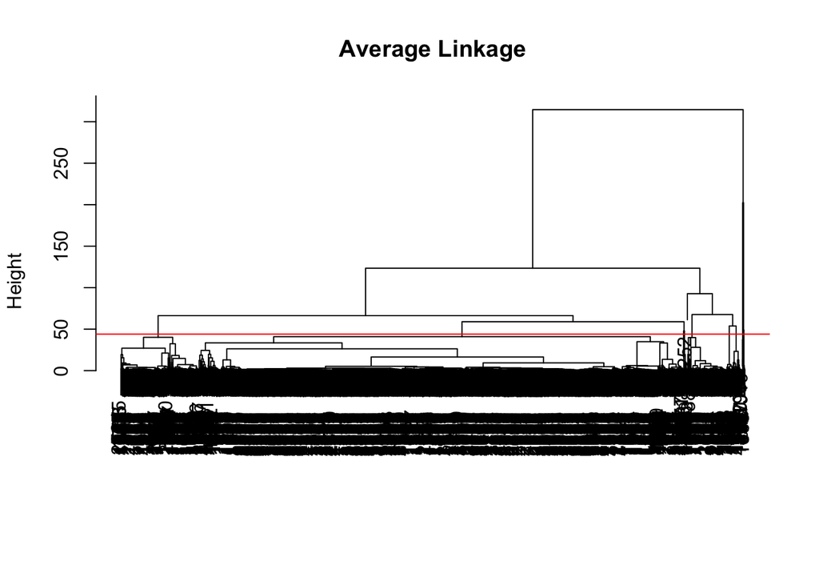

```r
plot(hc_average, main = "Average Linkage", xlab = "", sub = "")
abline(h = 44, col = 2)
```

```r
avgclust <- table(cutree(hc_average, 44))
avgclust
```

```
##
##   1   2   3   4   5   6   7   8   9  10  11  12  13  14  15  16  17  18
## 579 822  55  99 138   1  93 131  15   1   6   8  33   8   5   1  40  61
##  19  20  21  22  23  24  25  26  27  28  29  30  31  32  33  34  35  36
##  16  15  26  23  12   8   6   3  23  43   6   1   3   4   1   1   1   2
##  37  38  39  40  41  42  43  44
##   1   1   1   1   3   1   1   1
```

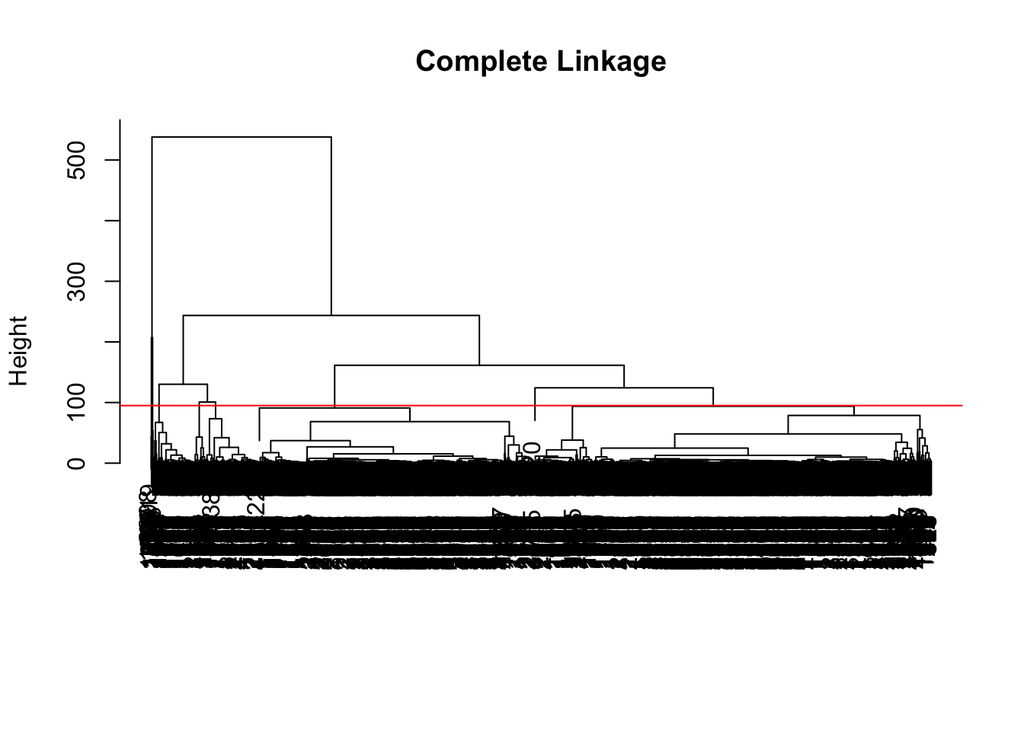

```r
plot(hc_complete, main = "Complete Linkage", xlab = "", sub = "")
abline(h = 95, col = 2)
```

```r
compclust <- table(cutree(hc_complete, 95))
compclust
```

```
##
##   1   2   3   4   5   6   7   8   9  10  11  12  13  14  15  16  17  18
## 302 103 109 443  29  48 128  37   1   6   4  32  32  97  11   1   1  45
##  19  20  21  22  23  24  25  26  27  28  29  30  31  32  33  34  35  36
##  21   8  10  18   7   5  89  41   1  27 144  33  13   6   2  13   5  15
##  37  38  39  40  41  42  43  44  45  46  47  48  49  50  51  52  53  54
##  15  13   9  10   9   8  43  23   6   6   2   2  12  87   8   9   5   1
##  55  56  57  58  59  60  61  62  63  64  65  66  67  68  69  70  71  72
##   5   5  19  10   2   1   7   3   1   8   2   2   2   1   1   8   3   1
##  73  74  75  76  77  78  79  80  81  82  83  84  85  86  87  88  89  90
##  13   1   1   2   6  11   1   1   4   2   1   1   1   1   3   1   2   1
##  91  92  93  94  95
##   6   1   2   1   1
```

We determine the number of clusters to use for each approach with dendrogram cutting. Single linkage clustering comes the closest to approximating clusters near the number of existing genres, however, it is inclined to place large numbers of observations in the first few clusteres and place only one observation in later clusters. Each method is prone to this to a degree. This may indicate that some music genres are not clearly delineated.

# Supervised Learning

## Testing vs Training

```r
set.seed(123)
## Create Testing and Training datasets
index <- createDataPartition(mdf$class, p = 2/3, list = FALSE)

training <- mdf[index, ]
testing <- mdf[-index,]
```

## LDA

Since the outcome we would like to predict, namely music genre, is recorded as unordered, categorical information, least squares regression could not appropriately discern observations into valid categories. Instead, we use linear discriminant analysis, which is a superior method to logistic regression when categories are well-defined, (such as with music genres) and additionally is often preferred when the outcome contains more than two classes, such as in this case.

```r
LDA <- lda(class ~ ., data = training)

LDApred <- predict(LDA, newdata = testing)

## Confusion Matrix
LDAconfusion <- table(prediction = LDApred$class, data = testing$class)

sort(
round((diag(LDAconfusion) / colSums(LDAconfusion)) * 100, 2),
decreasing = TRUE)
```

```
##          DrumAndBass            PsyTrance            HardDance
##                87.88                87.88                81.82
##   HardcoreHardTechno              BigRoom               Trance
##                66.67                63.64                60.61
##            GlitchHop            ReggaeDub            FunkRAndB
##                57.58                57.58                54.55
##              Minimal              Dubstep               Breaks
##                54.55                48.48                45.45
##     ProgressiveHouse               HipHop    IndieDanceNuDisco
##                45.45                42.42                42.42
## ElectronicaDowntempo                House            TechHouse
##                36.36                36.36                33.33
##         ElectroHouse            DeepHouse          FutureHouse
##                27.27                24.24                24.24
##               Techno                Dance
##                21.21                18.18
```

```r
## Percentage of Correct Classifications
mean(LDApred$class == testing$class)
```

```
## [1] 0.486166
```

The model performed best for classifying `DrumAndBass,` `PsyTrance,` and `HardDance.` It performed worst for `Techno` and `Dance`.

With a correct classification rate of approximately $48.6\%$ overall, this model performs substantially better than a baseline in which every genre is equally likely, where we might expect an accuracy rate of $\frac{1}{23} \approx 4\%$. However, it is possible that we could obtain a better rate using more sophisticated methods.

## Random Forest

In the context of classification, Random Forests provide a form averaging the predictions of many, *many*, classification trees using *bootstrapped* samples. The purpose of this is to reduce variance and, thus, creating a model that performs better in the testing dataset.

The following procedure is designed to choose two parameters:

- `mtry`: This parameter specifies a *random sample of m predictors* used to construct each individual tree. (Note: When `mtry` = “total number of predictors” we call this approach *bagging* instead of *random forest*).
- `treenum`: The number of trees used to perform the average. (This is not *that* important, but it is nice to choose them in way that doesn’t appear arbitrary).

```r
set.seed(123)

obb_err <- rep(NA, length(mdf) - 1) ## create placeholder for out-of-bag error
test_err <- rep(NA, length(mdf) - 1) ## create placeholder for test
treenum <- rep(NA, length(mdf) - 1) ## create placeholder for optimal number of trees

for (mtry in 1:length(obb_err)) {
  fit <- randomForest(class ~ ., data = mdf, subset = index, ntree = 1000,
                      mtry = mtry)

  treenum[mtry] <- which(fit$err.rate[1:1000] == min(fit$err.rate[1:1000]))[1]
  obb_err[mtry] <- fit$err.rate[treenum[mtry]]
  pred <- predict(fit, newdata = mdf[-index, ], type = "class")
  test_err[mtry] <- mean(pred != mdf[-index, ]$class)

  cat(mtry, "") ## This shows how long is the procedure taking in real-time.
}
```

```
## 1 2 3 4 5 6 7 8 9 10 11 12 13 14 15 16 17 18 19 20 21 22 23 24 25 26 27 28 29 30 31 32 33 34 35 36 37 38 39 40 41 42 43 44 45 46 47 48 49 50 51 52 53 54 55 56 57 58 59 60 61 62 63 64 65 66 67 68 69 70 71
```

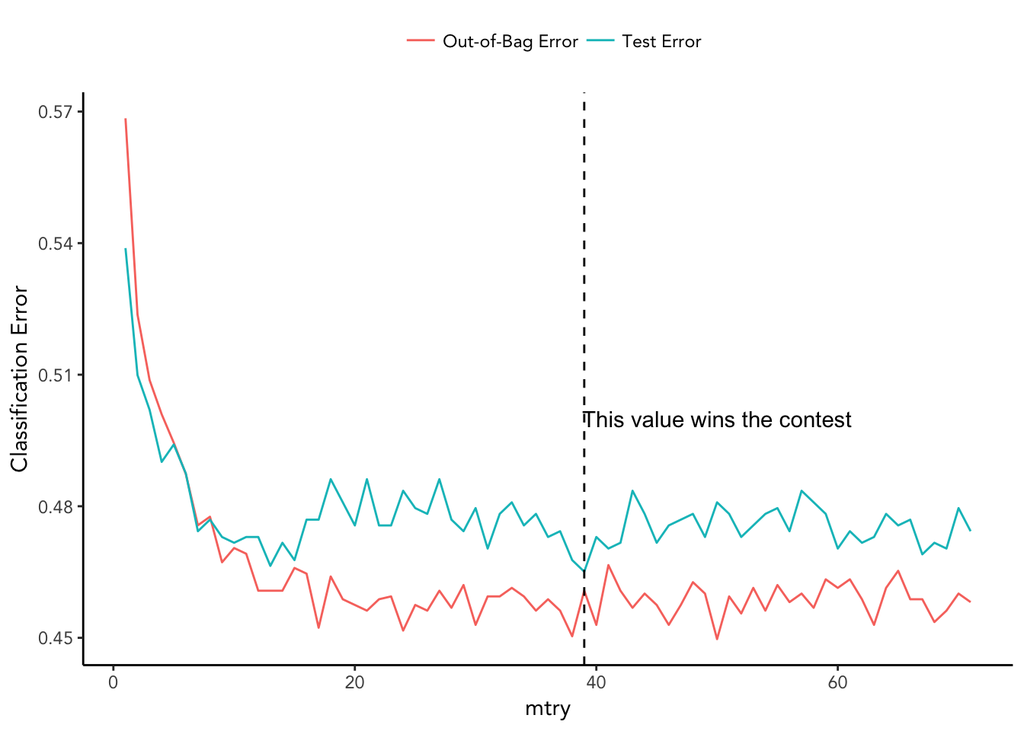

```r
set.seed(123)
## Model
mforest <- randomForest(formula = class ~ ., data = training,
                        mtry = which(test_err == min(test_err)),
                        ntree = treenum[which(test_err == min(test_err))],
                        importance = TRUE)

## Prediction Accuracy
forestpred <- predict(mforest, newdata = testing, type = "class")

forestconfusion <- table(prediction = forestpred, data = testing$class)

## Percentage of correct classifications
sort(
round((diag(forestconfusion) / colSums(forestconfusion)) * 100, 2),
decreasing = TRUE)
```

```
##            PsyTrance          DrumAndBass            HardDance
##                96.97                90.91                87.88
##               Trance            GlitchHop   HardcoreHardTechno
##                78.79                75.76                72.73
##               Breaks              Dubstep              Minimal
##                69.70                66.67                63.64
##              BigRoom          FutureHouse            ReggaeDub
##                60.61                45.45                45.45
## ElectronicaDowntempo            FunkRAndB            DeepHouse
##                42.42                42.42                39.39
##                House               HipHop     ProgressiveHouse
##                39.39                36.36                36.36
##    IndieDanceNuDisco         ElectroHouse            TechHouse
##                30.30                27.27                27.27
##                Dance               Techno
##                18.18                 9.09
```

```r
## Overall percentage of correct classifications
mean(forestpred == testing$class)
```

```
## [1] 0.5230567
```

This model –with a correct classification rate of $52.3\%$– performs better the LDA classifier as well as the baseline in which every genre is equally likely.

Just as it occured with LDA, the model performed best for classifying `PsyTrance`, `DrumAndBass`, and `HardDance` and performed worst for `Techno` and `Dance.`

Looking at the results, `Techno` was often misclassified as `TechHouse`, likely a sub-genre of `Techno`. Perhaps `TechHouse` is an intermediate between `Techno` and `ProgressiveHouse`, the most common misclassification for `Techno`.

Best and Worst Predictions

|  | PsyTrance | HardDance | Techno | Dance |
| --- | --- | --- | --- | --- |
| BigRoom | . | . | . | . |
| Breaks | . | . | 1 | 1 |
| Dance | . | . | . | 6 |
| DeepHouse | . | . | 2 | 3 |
| DrumAndBass | . | . | . | . |
| Dubstep | . | 3 | . | 1 |
| ElectroHouse | . | . | 1 | . |
| ElectronicaDowntempo | . | . | 2 | 1 |
| FunkRAndB | . | . | . | . |
| FutureHouse | . | . | . | 1 |
| GlitchHop | . | . | . | 5 |
| HardcoreHardTechno | . | . | 2 | . |
| HardDance | . | 29 | 1 | 1 |
| HipHop | . | . | . | 1 |
| House | . | . | 1 | 3 |
| IndieDanceNuDisco | . | 1 | . | 2 |
| Minimal | . | . | 3 | . |
| ProgressiveHouse | . | . | 10 | 1 |
| PsyTrance | 32 | . | . | . |
| ReggaeDub | . | . | . | 4 |
| TechHouse | . | . | 7 | 1 |
| Techno | . | . | 3 | 1 |
| Trance | 1 | . | . | 1 |

The following plots show the *importance* of each predictor for the model. The most important features are all related to *Beats Per Minute* (BPM).

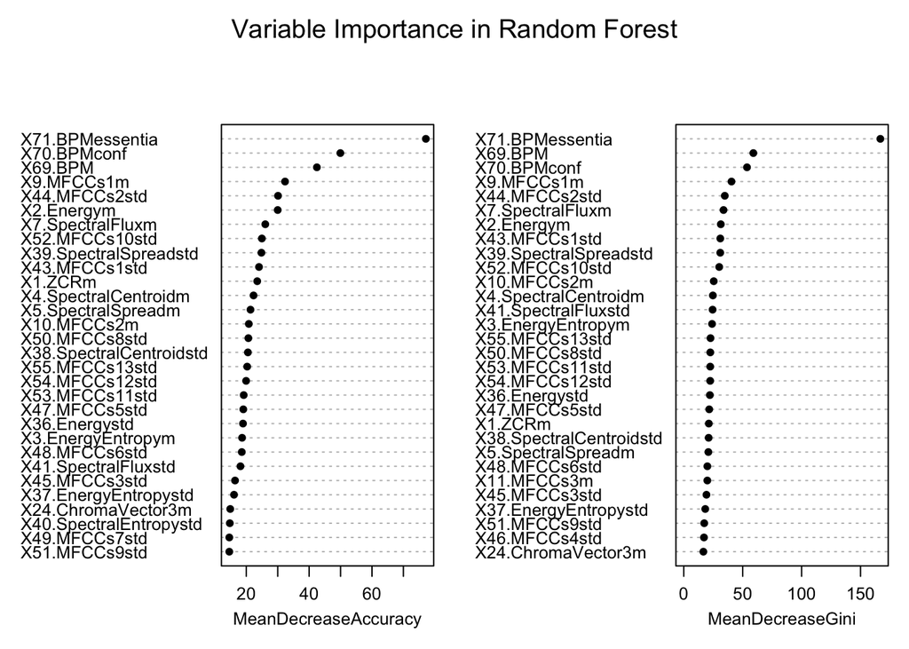

```r
set.seed(123)
varImpPlot(mforest, cex = 0.8,
           main = "Variable Importance in Random Forest", pch = 16)
```

We try a boosting approach as well to see if classification error can be reduced further. Unlike random forests, boosting uses the full set of training available available because it does not employ bootstrapping.

## Boosting

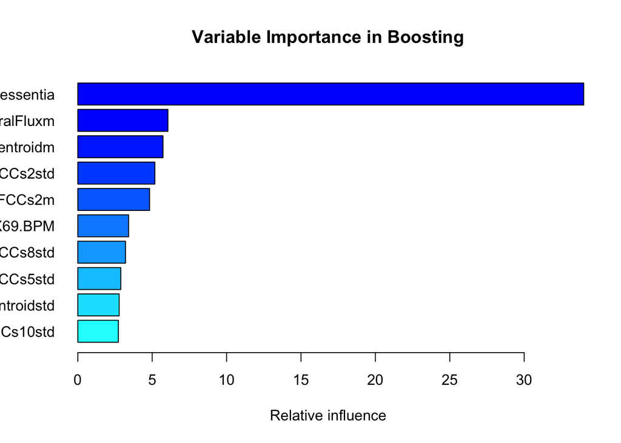

```
##                                             var      rel.inf
## X71.BPMessentia                 X71.BPMessentia 34.002740446
## X7.SpectralFluxm               X7.SpectralFluxm  6.057747374
## X4.SpectralCentroidm       X4.SpectralCentroidm  5.725017630
## X44.MFCCs2std                     X44.MFCCs2std  5.180121979
## X10.MFCCs2m                         X10.MFCCs2m  4.823552897
## X69.BPM                                 X69.BPM  3.414742097
## X50.MFCCs8std                     X50.MFCCs8std  3.208718639
## X47.MFCCs5std                     X47.MFCCs5std  2.889756275
## X38.SpectralCentroidstd X38.SpectralCentroidstd  2.778758988
## X52.MFCCs10std                   X52.MFCCs10std  2.728021912
## X43.MFCCs1std                     X43.MFCCs1std  2.522004258
## X41.SpectralFluxstd         X41.SpectralFluxstd  2.387555987
## X9.MFCCs1m                           X9.MFCCs1m  2.353079955
## X42.SpectralRolloffstd   X42.SpectralRolloffstd  2.185892514
## X55.MFCCs13std                   X55.MFCCs13std  2.038684236
## X70.BPMconf                         X70.BPMconf  1.967974180
## X54.MFCCs12std                   X54.MFCCs12std  1.877962475
## X53.MFCCs11std                   X53.MFCCs11std  1.545085644
## X37.EnergyEntropystd       X37.EnergyEntropystd  1.211322335
## X2.Energym                           X2.Energym  1.192701814
## X34.ChromaDeviationm       X34.ChromaDeviationm  1.058208046
## X49.MFCCs7std                     X49.MFCCs7std  0.945065676
## X35.ZCRstd                           X35.ZCRstd  0.890663862
## X39.SpectralSpreadstd     X39.SpectralSpreadstd  0.882324042
## X51.MFCCs9std                     X51.MFCCs9std  0.820820097
## X56.ChromaVector1std       X56.ChromaVector1std  0.786109098
## X23.ChromaVector2m           X23.ChromaVector2m  0.485439606
## X40.SpectralEntropystd   X40.SpectralEntropystd  0.420177621
## X57.ChromaVector2std       X57.ChromaVector2std  0.414899344
## X3.EnergyEntropym             X3.EnergyEntropym  0.385141791
## X48.MFCCs6std                     X48.MFCCs6std  0.295845494
## X15.MFCCs7m                         X15.MFCCs7m  0.287344424
## X11.MFCCs3m                         X11.MFCCs3m  0.256261799
## X45.MFCCs3std                     X45.MFCCs3std  0.228612045
## X32.ChromaVector11m         X32.ChromaVector11m  0.213487661
## X36.Energystd                     X36.Energystd  0.185350542
## X24.ChromaVector3m           X24.ChromaVector3m  0.151838010
## X67.ChromaVector12std     X67.ChromaVector12std  0.144177722
## X5.SpectralSpreadm           X5.SpectralSpreadm  0.142434040
```

[output cut: 17 more lines]

```
## X13.MFCCs5m                         X13.MFCCs5m  0.011435260
## X14.MFCCs6m                         X14.MFCCs6m  0.007073771
## X17.MFCCs9m                         X17.MFCCs9m  0.000000000
## X19.MFCCs11m                       X19.MFCCs11m  0.000000000
## X20.MFCCs12m                       X20.MFCCs12m  0.000000000
## X21.MFCCs13m                       X21.MFCCs13m  0.000000000
## X22.ChromaVector1m           X22.ChromaVector1m  0.000000000
## X25.ChromaVector4m           X25.ChromaVector4m  0.000000000
## X29.ChromaVector8m           X29.ChromaVector8m  0.000000000
## X31.ChromaVector10m         X31.ChromaVector10m  0.000000000
## X58.ChromaVector3std       X58.ChromaVector3std  0.000000000
## X62.ChromaVector7std       X62.ChromaVector7std  0.000000000
## X64.ChromaVector9std       X64.ChromaVector9std  0.000000000
## X66.ChromaVector11std     X66.ChromaVector11std  0.000000000
## X68.ChromaDeviationstd   X68.ChromaDeviationstd  0.000000000
```

```r
set.seed(123)
mdfboost <- gbm(class ~ ., n.trees = 3000,
                 distribution = "multinomial", data = training)

summary(mdfboost, main = "Variable Importance in Boosting",
        las = 1, cBars = FALSE)
```

```r
## Get classification
boostpred <- predict(mdfboost, newdata = testing, n.trees = 3000,
                        type = "response")
boostpred2 <- apply(boostpred, 1, which.max)
boostclass <- colnames(boostpred)[boostpred2]

## Confusion Matrix
boostconfusion <- table(prediction = boostclass, tdata = testing$class)

## Percentage of correct classifications
sort(
round((diag(boostconfusion) / colSums(boostconfusion)) * 100, 2),
decreasing = TRUE)
```

```
##            PsyTrance          DrumAndBass               Breaks
##                96.97                87.88                75.76
##            GlitchHop            HardDance              Dubstep
##                75.76                69.70                66.67
##               Trance              BigRoom              Minimal
##                63.64                60.61                57.58
##    IndieDanceNuDisco            FunkRAndB          FutureHouse
##                42.42                39.39                39.39
##   HardcoreHardTechno                House         ElectroHouse
##                39.39                36.36                33.33
##               Techno            ReggaeDub            TechHouse
##                30.30                24.24                24.24
##                Dance            DeepHouse     ProgressiveHouse
##                21.21                21.21                21.21
## ElectronicaDowntempo               HipHop
##                18.18                18.18
```

```r
## Proportion of Correct Predictions
mean(boostclass == testing$class)
```

```
## [1] 0.4624506
```

This classifier performs worse than both the LDA and random forest models, however its misclassification rate is not far off. Other similarities emerge in that `PsyTrance` and `DrumAndBass` are the most-accurately predicted. Further, `Techno` and `Dance` remain among the hardest genres to predict, though this model does perform better in that regard than others. A BPM-related variable emerges again as the most important for the classifier.

# Conclusions

Of the three classifier models, the random forest approach is best able to predict music genre based on the music analysis features. It is the only one to achieve a misclassification rate under 50%, although the other models approach this goal within five percentage points.

The models’ classification accuracies vary considerably between music genres, however. Certain genres, namely `PsyTrance` and `DrumAndBass` are consistently well-predicted, while `Dance` and `Techno` are often missclassified. Ostensibly similar genres, such as `Techno` and `HardcoreHardTechno` also tend to be confused. Possibly the models’ heavy reliance on BPM-related variables relative to others is related to this. It could be that broader categories such as `Techno` and `HardcoreHardTechno` are similar in tempo but differ in qualities related to sound texture. If this were the case, a model that classifies largely according to BPM may miss these distinctions. Additional support is lended to this hypothesis by PCA results, which maintain that BPM is a construct which is orthogonal to other audio-related constructs to a degree.

An alternative explanantion is that songs may be too finely categorized into overly granular genres based on subjective factors which are not well represented by audio analysis features. Evidence from clustering analysis is mixed and finds optimal numbers of clusters that are either fewer in quantity than the number of genres given in the data (16 vs. 23) or much larger (95 vs. 23). This suggests that classification could be improved either by distilling overly specific genres into larger overarching categories, (i.e. `HardcoreHardTechno` could be absorbed into `Techno`) or by another approach utilizing different features which more accurately represent the data’s genre categories. In either case, perhaps classification could be improved if genre data were quantitatively determined with a clustering or other similar function.